fossil

# Odds ratios that run high in small samples, dug back up.

We ran the study again: 281 sample sizes, 1,000 samples each, 281,000 logistic fits, and 20 more populations to see how far a rerun moves. Of 19 results, 4 came back exactly and 2 agree; 4 partly agree and 7 differ.

See every result

## Fig. 1

Fig. 1. Mean coefficient at each sample size from 100 to 1500 (1,000 samples each) and the fitted curve beta + b1/n, for the continuous and the discrete exposure. Ours is drawn on the published axes.

Differs

Published

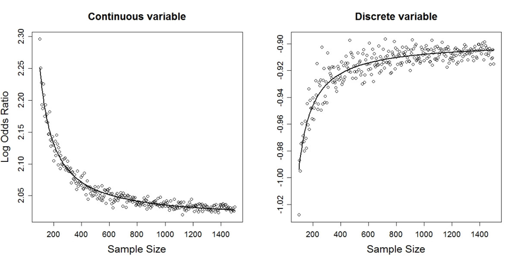

Our run

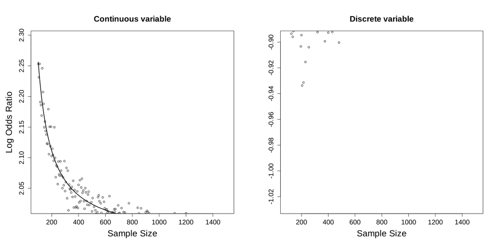

**Fig. 1, continuous variable**

11.8% within 2 px, Inconclusive

**Fig. 1, discrete variable**

0.4% within 2 px, Differs

Drawn on the published axes, 162 of our 281 means fall below them: our population sits lower (intercept 1.966 against 2.011) and our means scatter more. Moving our series by the difference of the intercepts raises the score from 12% to 54%; a population with x of SD 1 reaches 72%. These are hypothesis runs and are not counted as agreement; neither is a setting the paper states. 267 of our 281 means fall outside the published axes: our population's discrete coefficient is -0.840 (Table 1 -0.898) and our means have almost no 1/n trend (see table1.discrete). Moving our series by the difference of the intercepts gives 19%; a population with x of SD 1 gives 1%.

## Fig. 2

Fig. 2. Density of the continuous coefficient at six sample sizes, with the mean in each heading. Ours is drawn on the published axes.

Differs

Published

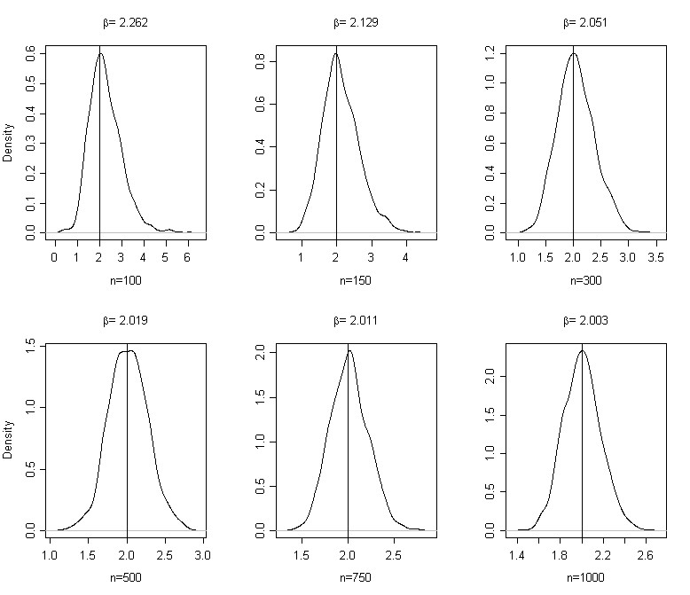

Our run

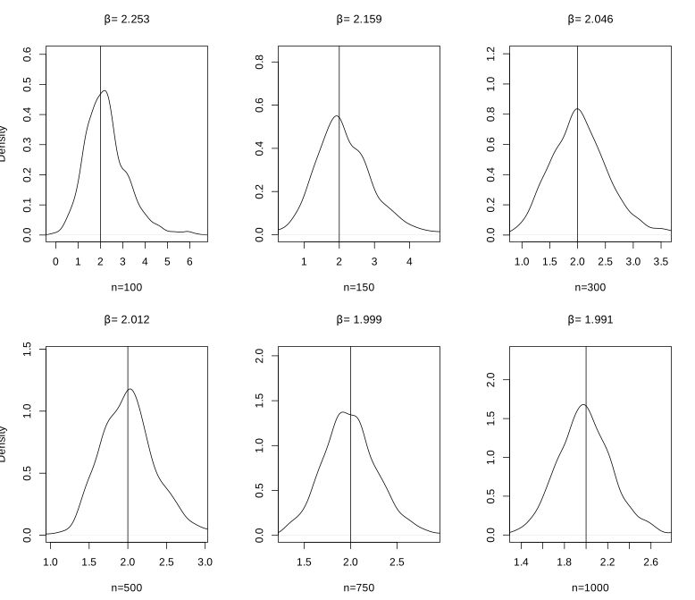

**Fig. 2, densities at n = 100, 150, 300, 500, 750 and 1000**

13.1% within 2 px, Differs

**Fig. 2, the mean in each panel heading**

0 of 6 values, Differs

Our densities are wider and lower: the sampling SD at n = 1000 is 0.25 to 0.27 over 21 populations, while the published curve's peak, read by eye at about 2.35, implies about 0.17. A kernel bandwidth 0.8 or 1.25 times ours does not help. A population with x of SD 1 (SD 0.20) raises the score from 13% to 54%. Each heading is a mean of 1,000 random estimates and is printed to three decimals, so it cannot come back exactly. Over 20 populations our means at five of the six sizes span the paper's heading; at n = 150 the paper's 2.129 is 0.006 below our lowest (2.135). Figs 2 and 3 also disagree with Table 1 (text.figures_vs_table1).

## Fig. 3

Fig. 3. Box plots of the continuous coefficient at the same six sample sizes. Ours is drawn on the published axes.

Differs

Published

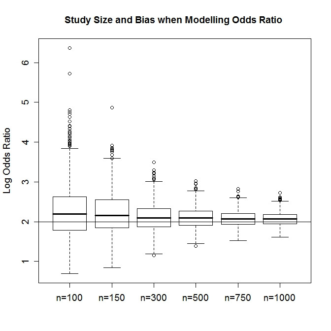

Our run

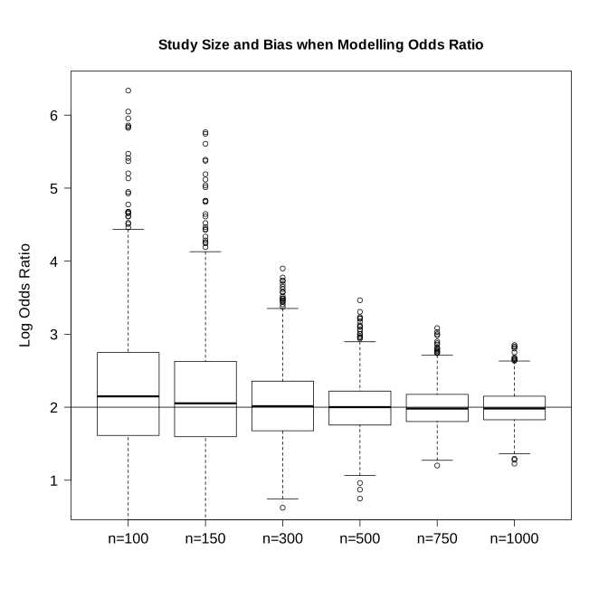

**Fig. 3, box plots at the same six sizes**

41.9% within 2 px, Differs

Our boxes are taller (our sampling spread is about 1.5 times the paper's) and our medians lower; the published medians, read by eye, stay near 2.07 to 2.2 at every size, above Fig. 2's means. The control shifted up by 1% of the axis scores better than ours, so a shift is part of the gap. A population with x of SD 1 raises the score from 42% to 60%.

## Table 1

OLS of the coefficient on 1/n. Ours fits the 281 per-size means (as Fig. 1 draws them); the next column fits all individual estimates. The spread is the range over 20 other populations. The last three columns are sensitivity runs, not agreement: only the fits R warns about left out, every fit kept, and a population with x of SD 1 in place of 0.7.

| Table 1 | Paper | Ours | Ours, all estimates | 20 populations | Sensitivity: warning rule | Sensitivity: every fit kept | Hypothesis: x SD 1 |
| --- | --- | --- | --- | --- | --- | --- | --- |
| Continuous, intercept | 2.011 | **1.966** | 1.966 | 1.962 to 2.023 | 1.963 | 1.642 | 2.009 |
| SE | 0.00072 | **0.00114** | 0.00112 | 0.00097 to 0.00124 | 0.00120 | 0.06433 | 0.00080 |
| t | 2785.9 | **1718.6** | 1757.9 | 1609.6 to 2066.8 | 1637.1 | 25.5 | 2503.4 |
| Continuous, n⁻¹ (b1) | 23.9 | **29.0** | 29.0 | 26.7 to 30.0 | 31.5 | 249.5 | 25.2 |
| SE | 0.276 | **0.438** | 0.437 | 0.371 to 0.476 | 0.459 | 24.626 | 0.307 |
| t | 86.48 | **66.16** | 66.29 | 59.20 to 76.90 | 68.66 | 10.13 | 82.11 |
| Continuous, R² | 0.963 | **0.940** | 0.015 | 0.926 to 0.955 | 0.944 | 0.269 | 0.960 |
| Discrete, intercept | -0.898 | **-0.855** | -0.854 | -0.956 to -0.866 | -0.765 | -0.675 | -0.860 |
| SE | 0.00065 | **0.00157** | 0.00130 | 0.00144 to 0.00191 | 0.00593 | 0.01774 | 0.00111 |
| t | -1369.34 | **-544.93** | -656.17 | -619.77 to -494.29 | -128.93 | -38.06 | -776.30 |
| Discrete, n⁻¹ (b1) | -9.524 | **-1.894** | -2.265 | -5.667 to -2.433 | -67.251 | -128.169 | -8.092 |
| SE | 0.251 | **0.601** | 0.509 | 0.552 to 0.732 | 2.270 | 6.789 | 0.424 |
| t | -37.92 | **-3.15** | -4.45 | -8.84 to -3.50 | -29.62 | -18.88 | -19.07 |
| Discrete, R² | 0.836 | **0.034** | 0.000 | 0.042 to 0.219 | 0.759 | 0.561 | 0.566 |

- Our population of 100,000 (seed 2724427): logistic fit 1.971 and -0.840; analytic first-order bias b1 23.8 and -10.7.
- Samples left out for separation or no convergence: 1406 of 281,000, all at n ≤ 370.

## Every result

Each verdict is computed from the numbers by check_results.py. Ours is one population (seed 2724427).

Result

Verdict

Measure

Why

Table 1, continuous variable (intercept and n⁻¹: estimate, SE, t, p)

Partly agrees

2 of 8 values

- Intercept estimate: paper 2.011, ours **1.966**
- Intercept SE: paper 0.00072, ours **0.00114**
- Intercept t-value: paper 2785.9, ours **1718.6**
- Intercept Pr(>|t|): paper <0.0001, ours **<0.0001**
- n⁻¹ estimate: paper 23.9, ours **29.0**
- n⁻¹ SE: paper 0.276, ours **0.438**
- n⁻¹ t-value: paper 86.48, ours **66.16**
- n⁻¹ Pr(>|t|): paper <0.0001, ours **<0.0001**

The intercept is the population draw: 2.011 lies inside our 20 populations (1.962 to 2.023; ours 1.966). The n⁻¹ slope and both SEs do not: b1 is 26.7 to 30.0 over 20 populations against 23.9, and the SEs are about 1.6 times the paper's, because our per-size means scatter more. The analytic first-order bias of our population is 23.8, close to the paper's 23.9. A population with x of SD 1 comes closer (b1 25.2, SE 0.307, intercept SE 0.00080) but does not close the gap.

Table 1, discrete variable (intercept and n⁻¹: estimate, SE, t, p)

Partly agrees

1 of 8 values

- Intercept estimate: paper -0.898, ours **-0.855**
- Intercept SE: paper 0.00065, ours **0.00157**
- Intercept t-value: paper -1369.34, ours **-544.93**
- Intercept Pr(>|t|): paper <0.0001, ours **<0.0001**
- n⁻¹ estimate: paper -9.524, ours **-1.894**
- n⁻¹ SE: paper 0.251, ours **0.601**
- n⁻¹ t-value: paper -37.92, ours **-3.15**
- n⁻¹ Pr(>|t|): paper <0.0001, ours **0.0018**

The intercept is the population draw: -0.898 lies inside our 20 populations (-0.956 to -0.866; ours, -0.855, lies just outside it). The slope does not come back: -1.9 here and -2.4 to -5.7 over 20 populations against -9.524, with SEs 2 to 3 times the paper's. Leaving out separated samples pulls the small-n means of the discrete coefficient toward zero; keeping the fits R does not warn about pushes them far away (b1 -67). The paper's rule is not stated. A population with x of SD 1 gives -8.1.

Text: R² of the OLS fit, 0.963 (continuous) and 0.836 (discrete)

Differs

0 of 2 values

- R², continuous: paper 0.963, ours **0.940**
- R², discrete: paper 0.836, ours **0.034**

Ours 0.940 and 0.034 against 0.963 and 0.836; over 20 populations 0.926 to 0.955 and 0.04 to 0.22. The R squared of the fit to all estimates is 0.015 and below 0.001, so the paper fitted the means. Our per-size means scatter more around the curve than the paper's, most for the discrete coefficient. A population with x of SD 1 gives 0.960 and 0.566. Follows table1.

Claims recomputed from the paper's own numbers (SE = estimate / t in Table 1; P(x>2.5) of Additional file 1)

Differs

In Table 1 the discrete intercept's printed estimate and t (-0.898, -1369.34) imply an SE of 0.000656, printed as 0.00065 (cut, not rounded). The other three SEs and P(x>2.5) come back.

The paper against itself: Fig. 2's headings and Table 1's curve 2.011 + 23.9/n

Differs

Fig. 2's headings are means at six sizes; Table 1's curve 2.011 + 23.9/n gives the means it implies. Five of six headings lie 0.03 to 0.04 below the curve (2.003 at n = 1000 against 2.035), and Fig. 3's medians, read by eye, sit higher still (about 2.07 at n = 1000). Figs 2 and 3 cannot come from the run behind Table 1 and Fig. 1.

Additional file 1: P(x>2.5) = 0.2375

Exact

1 of 1 values

- P(x>2.5), from x ~ N(2, 0.7): paper 0.2375, ours **0.2375**

Abstract and Results: estimates biased away from zero, odds ratios away from one

Partly agrees

4 of 5 values

- Continuous: mean estimate farther from zero than our population's coefficient at every size: paper yes, ours **yes**
- Discrete: mean estimate farther from zero than our population's coefficient at every size: paper yes, ours **no**
- Continuous coefficient: b1 > 0 (bias away from zero): paper yes, ours **yes**
- Discrete coefficient: b1 < 0 (bias away from zero): paper yes, ours **yes**
- Odds ratio of the continuous exposure at n = 100 above the large-sample value: paper yes, ours **yes**

Results: the fit is better for the continuous than for the discrete variable

Exact

1 of 1 values

- R² higher for the continuous than for the discrete coefficient: paper yes, ours **yes**

Results and Fig. 2: the sampling distribution is skewed at small n and grows symmetric

Exact

2 of 2 values

- Skewness of the continuous coefficient falls from n = 100 to n = 1000: paper yes, ours **yes**
- Skewness falls at each step of the six sizes of Fig. 2: paper yes, ours **yes**

Results and Fig. 3: extreme estimates become rarer as n grows

Exact

2 of 2 values

- Share of extreme estimates (beyond the box-plot whiskers) smaller at n = 1000 than at n = 100: paper yes, ours **yes**
- Largest estimate smaller at n = 1000 than at n = 100: paper yes, ours **yes**

Methods: kernel regression derivatives confirm the convergence rate

Partly agrees

2 of 4 values

- Continuous: kernel derivative has the sign of -b1/n² at every n from 150 to 1400: paper yes, ours **yes**
- Continuous: kernel derivative falls as n⁻² (log-log slope within 2 ± 0.5): paper yes, ours **yes**
- Discrete: kernel derivative has the sign of -b1/n² at every n from 150 to 1400: paper yes, ours **no**
- Discrete: kernel derivative falls as n⁻² (log-log slope within 2 ± 0.5): paper yes, ours **no**

The continuous coefficient's kernel derivative has the sign of -b1/n² everywhere and falls as n to the power -2.07. The discrete check fails because our discrete means have almost no 1/n trend (b1 -1.9, R² 0.03, see table1.discrete), which depends on the unstated handling of separated samples.

Discussion: maximum likelihood is risky under n = 100 and adequate above 500 (Long 1997)

Not attempted

A citation of Long (1997), not a result of the paper.

Fig. 1, continuous variable

Inconclusive

11.8% within 2 px

Drawn on the published axes, 162 of our 281 means fall below them: our population sits lower (intercept 1.966 against 2.011) and our means scatter more. Moving our series by the difference of the intercepts raises the score from 12% to 54%; a population with x of SD 1 reaches 72%. These are hypothesis runs and are not counted as agreement; neither is a setting the paper states.

Fig. 1, discrete variable

Differs

0.4% within 2 px

267 of our 281 means fall outside the published axes: our population's discrete coefficient is -0.840 (Table 1 -0.898) and our means have almost no 1/n trend (see table1.discrete). Moving our series by the difference of the intercepts gives 19%; a population with x of SD 1 gives 1%.

Fig. 2, densities at n = 100, 150, 300, 500, 750 and 1000

Differs

13.1% within 2 px

Our densities are wider and lower: the sampling SD at n = 1000 is 0.25 to 0.27 over 21 populations, while the published curve's peak, read by eye at about 2.35, implies about 0.17. A kernel bandwidth 0.8 or 1.25 times ours does not help. A population with x of SD 1 (SD 0.20) raises the score from 13% to 54%.

Fig. 2, the mean in each panel heading

Differs

0 of 6 values

- n=100: paper 2.262, ours **2.253**
- n=150: paper 2.129, ours **2.159**
- n=300: paper 2.051, ours **2.046**
- n=500: paper 2.019, ours **2.012**
- n=750: paper 2.011, ours **1.999**
- n=1000: paper 2.003, ours **1.991**

Each heading is a mean of 1,000 random estimates and is printed to three decimals, so it cannot come back exactly. Over 20 populations our means at five of the six sizes span the paper's heading; at n = 150 the paper's 2.129 is 0.006 below our lowest (2.135). Figs 2 and 3 also disagree with Table 1 (text.figures_vs_table1).

Fig. 3, box plots at the same six sizes

Differs

41.9% within 2 px

Our boxes are taller (our sampling spread is about 1.5 times the paper's) and our medians lower; the published medians, read by eye, stay near 2.07 to 2.2 at every size, above Fig. 2's means. The control shifted up by 1% of the axis scores better than ours, so a shift is part of the gap. A population with x of SD 1 raises the score from 42% to 60%.

simulate_population() against the R lines of Additional file 1

Agrees

R package logitbias and its tutorial

Agrees

The main claim holds in part: both slopes b1 point away from zero, the continuous mean lies farther from zero than the population value at every size, and the sampling distribution is skewed at small n and grows symmetric; the discrete mean does so at 257 of 281 sizes, and leaving out separated samples pulls it toward zero at n = 100 to 120. Table 1's slopes, SEs and R squared values and the figures' spreads do not come back; those causes are open (the paper's per-size means scatter less than any population of Additional file 1's design gives), and the intercepts move with the population draw.

## What came back

**The direction of the bias**

Both slopes point away from zero; the continuous mean lies above the population value at every size, the discrete mean beyond it at 257 of 281.

**The shape**

Skewed at n = 100, near symmetric at n = 1000; fewer extreme estimates as n grows.

**The intercepts**

2.011 and -0.898 lie inside our 20 populations.

**The population**

Additional file 1's R lines run unchanged, and P(x>2.5) = 0.2375.

## What stayed buried

- Table 1's slopes, SEs and R squared values: our means scatter more than the paper's.
- The spreads of Figs 2 and 3: about 1.5 times wider in our run.
- How the paper handled separated samples, and its seed.

The main claim holds in part: both slopes b1 point away from zero, the continuous mean lies farther from zero than the population value at every size, and the sampling distribution is skewed at small n and grows symmetric; the discrete mean does so at 257 of 281 sizes, and leaving out separated samples pulls it toward zero at n = 100 to 120. Table 1's slopes, SEs and R squared values and the figures' spreads do not come back; those causes are open (the paper's per-size means scatter less than any population of Additional file 1's design gives), and the intercepts move with the population draw.

## What we matched

Each line is a part of the paper and how close our run came.

**Table 1**

Intercepts within the spread of 20 populations; slopes and SEs not.

**Fig. 1**

Most of our points fall off the published axes; the scores sit among the controls.

**Figs 2 and 3**

Same shapes, wider spreads.

**The text**

Bias away from zero, skew and extremes all come back; the discrete kernel check does not.